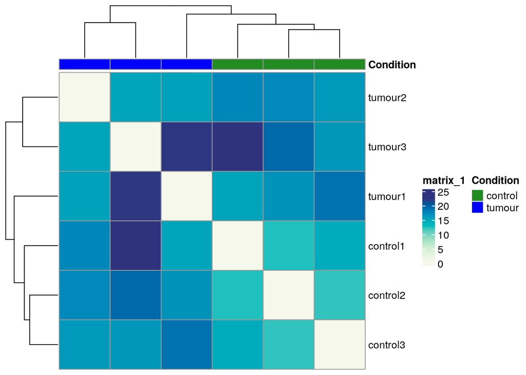

```r
#This line voids the column names from the matrix
colnames(sampleDistMatrix) <- NULL

#This line produces a data frame from the sample conditions in 'samples'.
ann <- data.frame(Condition = samples$condition)

#These format the top section in the graph below assigning colours to sample conditions.
col <- c("blue", "forestgreen")
names(col) <- c("tumour", "control")
ann_col <- list(Condition = col)

#This uses the row names from thematric for the annotation data frame.
rownames(ann) <- rownames(sampleDistMatrix)

#This generates the heat map below and formats the layout and colours.
pheatmap(mat=sampleDistMatrix,
         clustering_distance_rows=sampleDists,
         clustering_distance_cols=sampleDists,
         annotation_col = ann,
         annotation_colors = ann_col,
         col=hcl.colors(100,"GnBu",rev=T))
```

This is a heat map that uses colour, white for low difference in gene expression and dark blue for large difference in gene expression. The white squares show there’s no difference in gene expression because these squares compare the same condition. when comparing the squares of the different controls (9 squares in bottom right corner), the colours are light indicating low levels of gene variation. The is a high level of differentiation between tumour 1 and tumour 3. Also between tumour 3 and control 1. The rest of the squares are light to dark ish blue showing not as much difference in expression as the two pairs stated before.

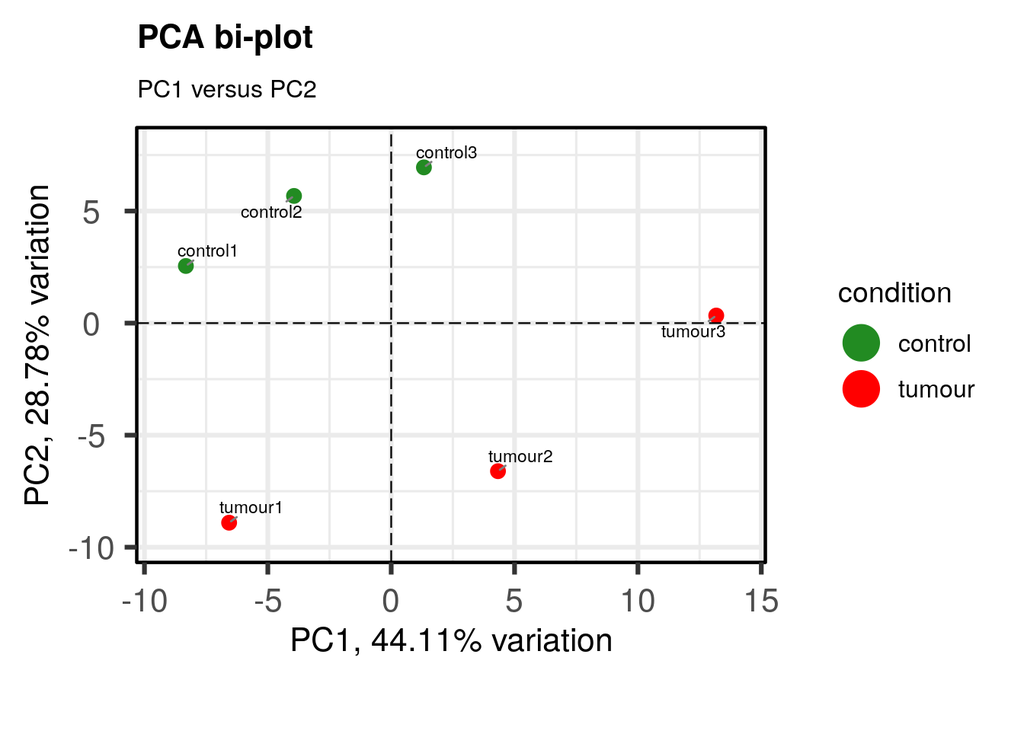

```r
#the pca() function performs a principal component analysis on the rld counts and 'samples' metadata.
p <- pca(rld_counts, metadata = samples)

#This code creates and formats a biplot using the results from the principal component analysis.
biplot(p,
       colby = 'condition',
       colkey = c('tumour'='red1', 'control'='forestgreen'),
       hline = 0,
       vline = 0,
       legendPosition = 'right',
       legendLabSize = 12,
       legendIconSize = 8.0,
       title = 'PCA bi-plot',
       subtitle = 'PC1 versus PC2')
```

```r
#comparison of the the differential expression of genes in thetumour and control at the 5% significance level.
tumour_v_ctrl <- results(dds, filterFun=ihw, alpha=0.05, c("condition", "tumour", "control"))

#These lines of codes are about shrinking the data stored in dds for it to be more managable for analysis. The type of shrinkage method used is APEglm.
res1 <- lfcShrink(dds=dds, res=tumour_v_ctrl, coef=2, type="apeglm")
```

```
## using 'apeglm' for LFC shrinkage. If used in published research, please cite:
##     Zhu, A., Ibrahim, J.G., Love, M.I. (2018) Heavy-tailed prior distributions for
##     sequence count data: removing the noise and preserving large differences.
##     Bioinformatics. https://doi.org/10.1093/bioinformatics/bty895
```

```r
summary(res1)
```

```
##
## out of 21474 with nonzero total read count
## adjusted p-value < 0.05
## LFC > 0 (up)       : 254, 1.2%
## LFC < 0 (down)     : 205, 0.95%
## outliers [1]       : 0, 0%
## [1] see 'cooksCutoff' argument of ?results
## see metadata(res)$ihwResult on hypothesis weighting
```

```r
#This set of code assigns the upregulated genes, genes with a fold change greater than or equal to 1, to key and to the name get_upregulated.
get_upregulated <- function(df){
    key <- intersect(rownames(df)[which(df$log2FoldChange>=1)], rownames(df)[which(df$pvalue<=0.05)])
  results <- as.data.frame((df)[which(rownames(df) %in% key),])
    return(results)
}
```

```r
#This set of code assigns the down regulated genes, genes with a fold change greater than or equal to 1, to key and to the name get_downregulated.
get_downregulated <- function(df){
    key <- intersect(rownames(df)[which(df$log2FoldChange<=-1)], rownames(df)[which(df$pvalue<=0.05)])
    results <- as.data.frame((df)[which(rownames(df) %in% key),])
    return(results)
}
```

```r
#This function adds additional information to the genes gtom the database Ensemble
annotate_de_genes <- function(df){

    df$hgnc_symbol <- rownames(df)
    mart <- useMart(biomart = "ensembl", dataset = "hsapiens_gene_ensembl")
    info <- getBM(attributes=c("hgnc_symbol",
                               "ensembl_gene_id_version",
                               "chromosome_name",
                               "start_position",
                               "end_position",
                               "strand",
                               "entrezgene_description"),
                  filters = c("hgnc_symbol"),
                  values = df$hgnc_symbol,
                  mart = mart,
                  useCache=FALSE)

    #these lines merge the gene symbols with the additional information, replace 1s with '-' or '+' and removes unwanted chromosomes
    tmp <- merge(df, info, by="hgnc_symbol")
    tmp$strand <- gsub("-1", "-", tmp$strand)
    tmp$strand <- gsub("1", "+", tmp$strand)
    tmp$hgnc_symbol <- make.names(tmp$hgnc_symbol, unique = T)
    tmp <- tmp[!grepl("CHR", tmp$chromosome_name),]

    #sorts the data and reorganises it.
    output_col <- c("Gene", "Ensembl ID", "Chromosome", "Start", "Stop", "Strand", "Description", "Log2FC", "P-value", "Adj P-value")
    tmp <- subset(tmp, select=c(hgnc_symbol, ensembl_gene_id_version, chromosome_name, start_position, end_position, strand, entrezgene_description, log2FoldChange, pvalue, padj))
    colnames(tmp) <- output_col

    if(min(tmp$Log2FC) > 0){
        tmp <- tmp[order(-tmp$Log2FC),]
    }else{
        tmp <- tmp[order(tmp$Log2FC),]
    }

    return(tmp)

}
#returns an annotated data frame
```

```r
#Extraction of the upregulated and down regulated gene from the data frame res1. Then the genes are annotated with the inofrmation specified in the last chunk of code.
de_up <- get_upregulated(as.data.frame(res1))
de_down <- get_downregulated(as.data.frame(res1))
upregulated_genes <- annotate_de_genes(de_up)
downregulated_genes <- annotate_de_genes(de_down)

#this is to check that the code works by outputting the top of the table.
head(upregulated_genes)
```

```
##        Gene         Ensembl ID Chromosome     Start      Stop Strand
## 35    ID3.1  ENSG00000117318.9          1  23557926  23559501      -
## 44   MAGEA4 ENSG00000147381.12          X 151912495 151925171      +
## 32      ID1  ENSG00000125968.9         20  31605283  31606515      +
## 53   PDPR2P  ENSG00000214331.9         16  74332567  74360859      -
## 2  ADAMTS12 ENSG00000151388.11          5  33523535  33892019      -
## 62 SERPINA3 ENSG00000196136.18         14  94612384  94624055      +
##                                                  Description   Log2FC
## 35                                inhibitor of DNA binding 3 5.340037
## 44                                     MAGE family member A4 5.249618
## 32                                inhibitor of DNA binding 1 4.655481
## 53                                                           4.404639
## 2  ADAM metallopeptidase with thrombospondin type 1 motif 12 4.023226
## 62                                  serpin family A member 3 2.538597
##         P-value  Adj P-value
## 35 2.926086e-53 7.993740e-50
## 44 3.344444e-04 4.246152e-01
## 32 8.011823e-07 5.199150e-04
## 53 1.344097e-07 1.073515e-04
## 2  2.251320e-10 2.327975e-07
## 62 1.424347e-09 9.387061e-07
```

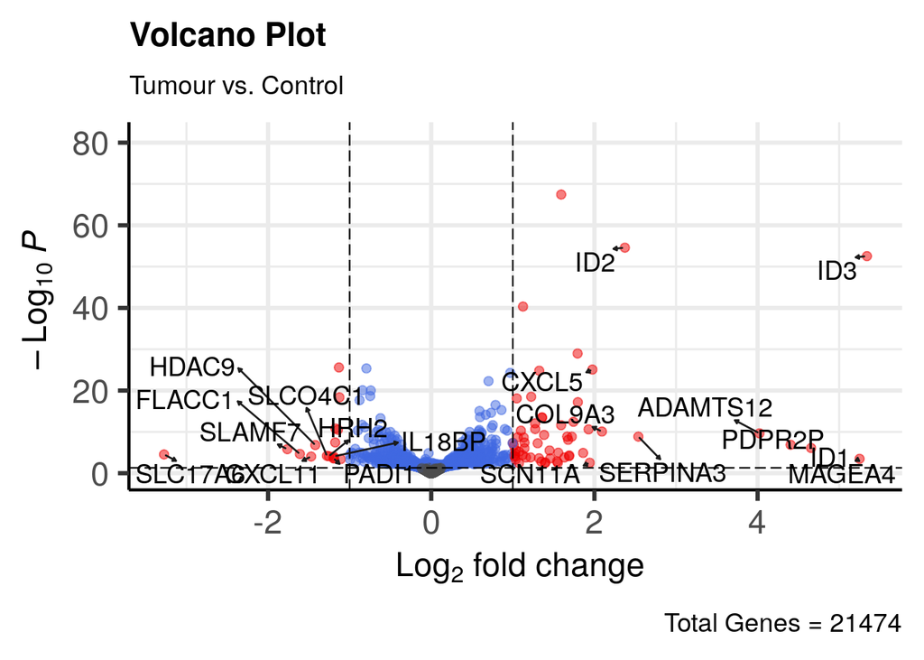

```r
#Removes rows with missing values from res1
res1 <- na.omit(res1)

#Calculate min/max axis values for plot
min_width <- min(res1$log2FoldChange)
max_width <- max(res1$log2FoldChange)
max_height <- -log10(min(res1[res1$pvalue>0, 5]))

#Show top 10 up-regulated genes for plot
up <- subset(res1, res1$log2FoldChange > 1 & res1$pvalue <= 0.05)
up <- up[order(-up$log2FoldChange),]
up_list <- head(rownames(up), n=10L)

#Show top 10 down regulated genes for plot
down <- subset(res1, res1$log2FoldChange < -1 & res1$pvalue <= 0.05)
down <- down[order(down$log2FoldChange),]
down_list <- head(rownames(down), n=10L)

# place top 20 DE genes in vector
plot_top_20 <- c(up_list, down_list)

#This creates the a volcano plot and formats it.
EnhancedVolcano(res1,
                lab=rownames(res1),
                x="log2FoldChange",
                y="pvalue",
                selectLab=plot_top_20,
                drawConnectors=TRUE,
                legendPosition = "none",
                FCcutoff=1.0,
                pCutoff=0.05,
                title="Volcano Plot",
                subtitle="Tumour vs. Control",
                caption = paste0('Total Genes = ', nrow(res1)),
                xlim=c(min_width, max_width),
                ylim=c(0, max_height))
```

Volcano plots are a way to visualize and identify genes that are both statistically significant and biologically relevant in terms of their expression changes between the control and tumour conditions. Dots spread horizontally indicate greater difference in gene expression. Dots higher in the graph indicate changes of great statistical significance. Red dots are genes with a significant log2 fold change which are considered differentially expressed. Blue dots represent genes with no significant change.

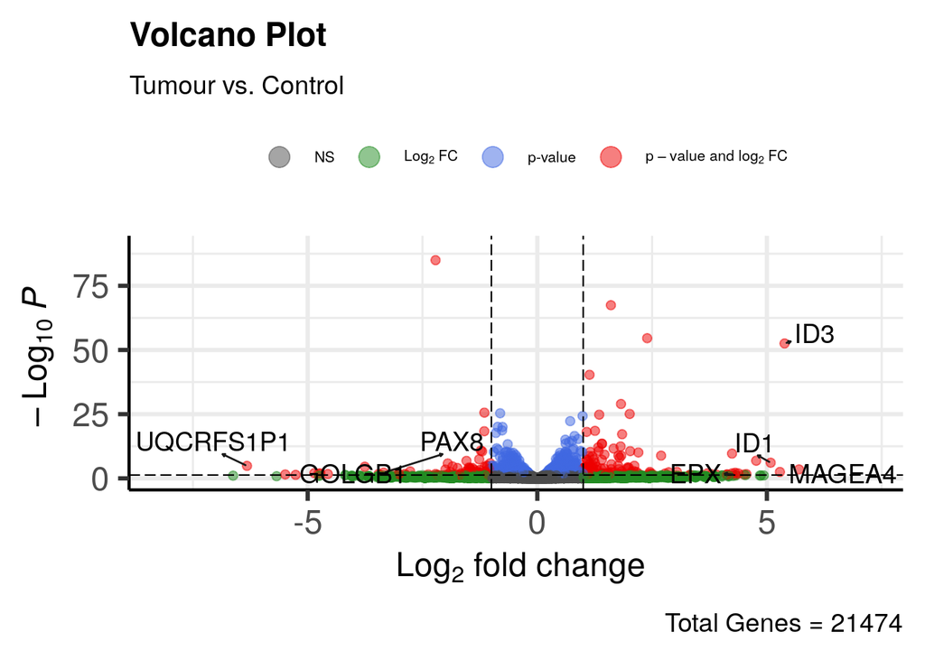

```r
#Removes rows with missing values from tumour vs control
res1 <- na.omit(tumour_v_ctrl)

#Calculate min/max axis values for plot
min_width <- min(res1$log2FoldChange)
max_width <- max(res1$log2FoldChange)
max_height <- -log10(min(res1[res1$pvalue>0, 5]))

#Show top 10 up-regulated genes for plot
up <- subset(res1, res1$log2FoldChange > 1 & res1$pvalue <= 0.05)
up <- up[order(-up$log2FoldChange),]
up_list <- head(rownames(up), n=10L)

#Show top 10 down regulated genes for plot
down <- subset(res1, res1$log2FoldChange < -1 & res1$pvalue <= 0.05)
down <- down[order(down$log2FoldChange),]
down_list <- head(rownames(down), n=10L)

#Combines the two lists
plot_top_20 <- c(up_list, down_list)

#This creates a volcano plot and formats it.
EnhancedVolcano (res1,
                      lab=rownames(res1),
                    x="log2FoldChange",
                    y="pvalue",
                    selectLab=plot_top_20,
                    drawConnectors=TRUE,
                    FCcutoff=1.0,
                    pCutoff=0.05,
                    title="Volcano Plot",
                    subtitle="Tumour vs. Control",
                    legendLabSize=8,
                    caption = paste0('Total Genes = ', nrow(res1)))
```

The red dots outside the two vertical lines indicate greater variance in gene expression. Genes on the right are up regulated while the genes to the right are down regulated. Red dots are genes with a significant log2 fold change which are considered differentially expressed. Genes higher up in the graph vertically indicate genes with changes in gene expression of significance. Genes furthest from the center of the graph are the genes of significance in the context of comparing the two conditions, control and tumour.

```r
#Removes rows with missing values from res1
res1 <- na.omit(res1)
```

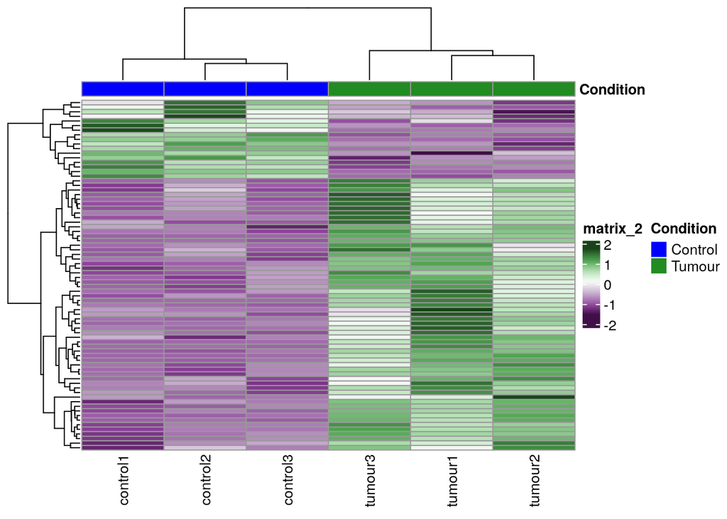

```r
#Chooses the first 6 genes from the rld counts
subset <- rld_counts[, 1:6]

#
up <- rownames(de_up)
down <- rownames(de_down)

#isolates the data from only up or down regulated genes
key <- c(up, down)
subset <- subset[which(rownames(subset) %in% key),]

mat <- as.matrix(scale(t(subset), center = T))

#This code is assigning names and colours to both conditions
ann <- data.frame(Condition = c(rep("Control", 3), rep("Tumour", 3)))
rownames(ann) <- rownames(mat)
col <- c("blue", "forestgreen")
names(col) <- c("Control", "Tumour")
ann_col <- list(Condition = col)

#This creates a heat map and formats it.
pheatmap(t(mat),
         show_rownames = FALSE,
         annotation_col = ann,
         annotation_colors = ann_col,
         color = hcl.colors(100, "PRGn",rev=F))
```

This heat map displays the genes that have significance in comparing the up regulated and down regulated genes of the two conditions. The darker colour rectangles indicate a greater difference in gene expression.Rectangles that are white or of lighter colours have little difference in gene expression. The green genes are up regulated while the purple genes are down regulated. You can compared the two conditions by looking for clusters of genes that differ between the two conditions that may be biologically relevant.

```r
#converts re1 into a data frame and adds a column with the gene symbols.
res <- as.data.frame(res1)
res$hgnc_symbol <- rownames(res)

#compute summary stat
fgsea_rank <- res %>%
              dplyr::select(hgnc_symbol, log2FoldChange) %>%
              na.omit() %>%
              distinct() %>%
              group_by(hgnc_symbol) %>%
              summarize(stat=mean(log2FoldChange))
#fgsea_rank data frame contains the summary statistics just calculated
fgsea_rank
```

```
## # A tibble: 21,474 × 2
##    hgnc_symbol     stat
##    <chr>          <dbl>
##  1 ""          -0.0138
##  2 "A1BG"      -0.0655
##  3 "A1CF"      -0.233
##  4 "A2M"       -0.178
##  5 "A2ML1"      2.03
##  6 "A2MP1"      0.405
##  7 "A3GALT2"   -0.00376
##  8 "A4GALT"     1.61
##  9 "A4GNT"     -0.520
## 10 "AAAS"      -0.0501
## # ℹ 21,464 more rows
```

This table displays the genes and their log2 fold change between tumour and control.

```r
#conversion of fgsea_rank inot a vector named rank and showing the top of the vector
rank <- deframe(fgsea_rank)
head(rank, 20)
```

```
##                      A1BG         A1CF          A2M        A2ML1        A2MP1
## -0.013801174 -0.065514617 -0.233400538 -0.178211072  2.030175987  0.405383438
##      A3GALT2       A4GALT        A4GNT         AAAS         AACS       AACSP1
## -0.003763415  1.605835820 -0.519808115 -0.050086633 -0.233841770 -1.451488721
##        AADAC      AADACL3      AADACL4        AADAT        AAGAB         AAK1
## -0.965544095 -0.003763415  1.846447804  0.137083135 -0.189725937  0.319957981
##        AAMDC         AAMP
## -0.060705327 -0.025364106
```

```r
#loading the gene names and displaying them
pathway <- gmtPathways("/home/rstudio/c6.all.v2023.2.Hs.symbols.gmt")
head(pathway, 1)
```

```
## $AKT_UP.V1_DN
##   [1] "ACKR3"    "ADGRL1"   "ADHFE1"   "ALPL"     "AMPD2"    "ANGPTL4"
##   [7] "AQP5"     "ASF1A"    "ASS1"     "AXIN2"    "BCS1L"    "BEX4"
##  [13] "BLVRB"    "BTBD2"    "C11orf71" "C1R"      "C1S"      "CAP2"
##  [19] "CAV2"     "CBS"      "CD248"    "CDC42BPA" "CDH16"    "CDPF1"
##  [25] "CELA1"    "CHAD"     "CHN2"     "CHST12"   "CNN2"     "COL17A1"
##  [31] "CSDC2"    "DNAJA3"   "DPT"      "DRAM1"    "EDARADD"  "EFEMP1"
##  [37] "EFEMP2"   "EIF4E3"   "ESR2"     "EXOSC1"   "FAH"      "FAM20C"
##  [43] "FANK1"    "FAS"      "FBXO32"   "FHOD3"    "FKBP11"   "FMO2"
##  [49] "FMO3"     "FUT10"    "FUT8"     "FXYD1"    "G6PC2"    "GALNT16"
##  [55] "GAS1"     "GATAD2B"  "GHR"      "GNA14"    "GNMT"     "GRAMD1A"
##  [61] "GSPT2"    "GSTA4"    "HEBP1"    "HIC1"     "HMGCS2"   "HPS1"
##  [67] "HTRA1"    "IBSP"     "ID3"      "IFFO1"    "IFRD2"    "IL13RA1"
##  [73] "IL17RC"   "IRS1"     "IRS2"     "ISLR"     "ITGBL1"   "ITIH5"
##  [79] "ITPKB"    "KCNK3"    "KCNN4"    "KCTD12"   "KLF2"     "KRT15"
```

[output cut: 18 more lines]

```r
#using the fgsea function to do an analysis
fgsea <- fgsea(pathways=pathway, stats=rank, nperm=1000)
#conversion of results so they can be used in the tidyverse package
fgseaResTidy <- fgsea %>%
  as_tibble() %>%
  arrange(desc(NES))

#Display the results
fgseaResTidy %>%
  dplyr::select(-leadingEdge, -ES, -nMoreExtreme) %>%
  arrange(padj) %>%
  DT::datatable()
```

|  | pathway | pval | padj | NES | size |
| --- | --- | --- | --- | --- | --- |
| 1 | KRAS.AMP.LUNG_UP.V1_DN | 0.01772525849335303 | 0.9264705882352942 | 1.375461920761721 | 123 |
| 2 | PRC2_EED_DN.V1_DN | 0.01030927835051546 | 0.9264705882352942 | -1.27878455613628 | 191 |
| 3 | MTOR_UP.V1_UP | 0.0196078431372549 | 0.9264705882352942 | -1.303675066456314 | 163 |
| 4 | CSR_LATE_UP.V1_DN | 0.006153846153846154 | 0.9264705882352942 | -1.427591838254048 | 140 |
| 5 | HINATA_NFKB_IMMU_INF | 0.02572898799313894 | 0.9337175792507205 | 1.56704653454861 | 15 |
| 6 | ESC_J1_UP_EARLY.V1_DN | 0.0345821325648415 | 0.9337175792507205 | 1.287621727062927 | 166 |
| 7 | GCNP_SHH_UP_LATE.V1_UP | 0.03311258278145696 | 0.9337175792507205 | -1.247209257163784 | 177 |
| 8 | WNT_UP.V1_UP | 0.04597701149425287 | 1 | 1.283183308820263 | 158 |
| 9 | P53_DN.V2_UP | 0.09566517189835576 | 1 | 1.198017692946014 | 135 |
| 10 | KRAS.LUNG_UP.V1_UP | 0.1124437781109445 | 1 | 1.197112470385246 | 116 |

[output cut: 179 more lines]

```r
#Only show results with and Normalization Enrichment score greater thank 1.29
filtered_pathway <- subset(fgsea, NES > 1.29)
filtered_pathway
```

```
##                   pathway       pval      padj        ES      NES nMoreExtreme
## 1:   HINATA_NFKB_IMMU_INF 0.02572899 0.9337176 0.7361721 1.567047           14
## 2: KRAS.AMP.LUNG_UP.V1_DN 0.01772526 0.9264706 0.4504406 1.375462           11
##    size                              leadingEdge
## 1:   15     OLR1,CXCL3,CXCL2,CXCL6,IL6,CXCL8,...
## 2:  123 MC2R,CEND1,SLC5A2,CACNA1F,GNAT3,HBA1,...
```

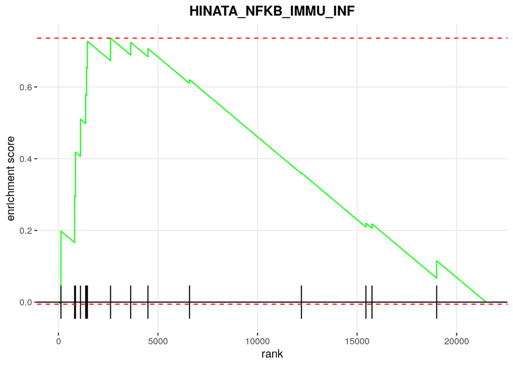

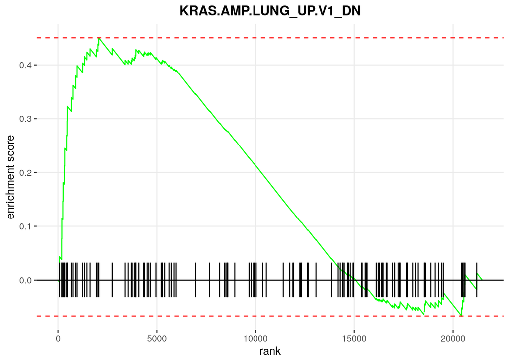

```r
#converts filtered_pathway to a vector
filt_up <- as.vector(filtered_pathway$pathway)

#Outputs an enrichment plot for genes with an NES greater than 1.29. Outlines the format and design of the plot
for (i in filt_up){
    plt <- plotEnrichment(pathway = pathway[[i]],
    gseaParam = 1, ticksSize = 0.5, stats= rank) +
    labs(title=i) + theme(plot.title = element_text(hjust = 0.5, face="bold"))
    print(plt)
    }
```

```r
#Only show results with and Normalization Enrichment score less than -1.3
filtered_pathway <- subset(fgsea, NES < -1.3)
filtered_pathway
```

```
##              pathway        pval      padj         ES       NES nMoreExtreme
## 1:    CAHOY_NEURONAL 0.055555556 1.0000000 -0.4187946 -1.304985           19
## 2: CSR_LATE_UP.V1_DN 0.006153846 0.9264706 -0.4266370 -1.427592            1
## 3:     MTOR_UP.V1_UP 0.019607843 0.9264706 -0.3821487 -1.303675            5
##    size                                    leadingEdge
## 1:   87 CALN1,SLC17A6,KCNIP4,SLC35F4,GLRA2,RTN4RL1,...
## 2:  140     MRGPRF,TCEAL7,NTN4,HMGCS1,APOL3,INSIG1,...
## 3:  163       BLK,MBL1P,SIGLEC1,RGS11,MGARP,HMGCS1,...
```

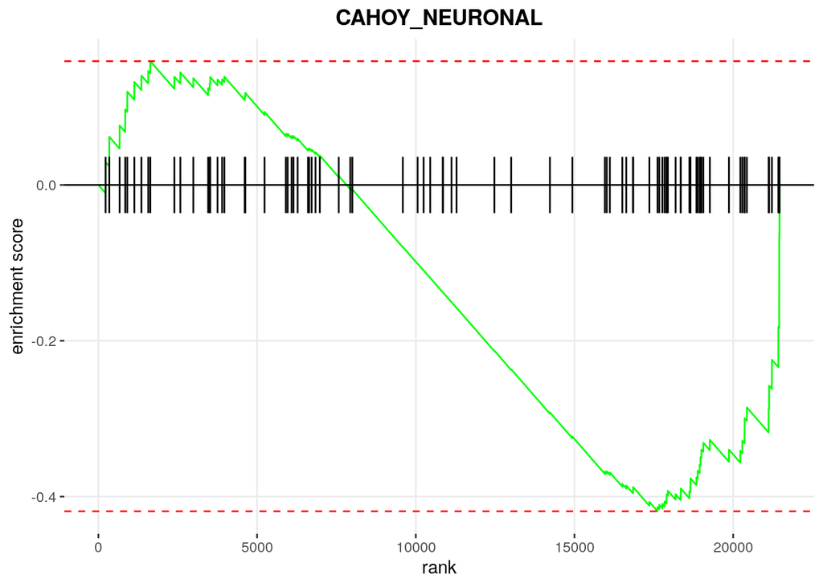

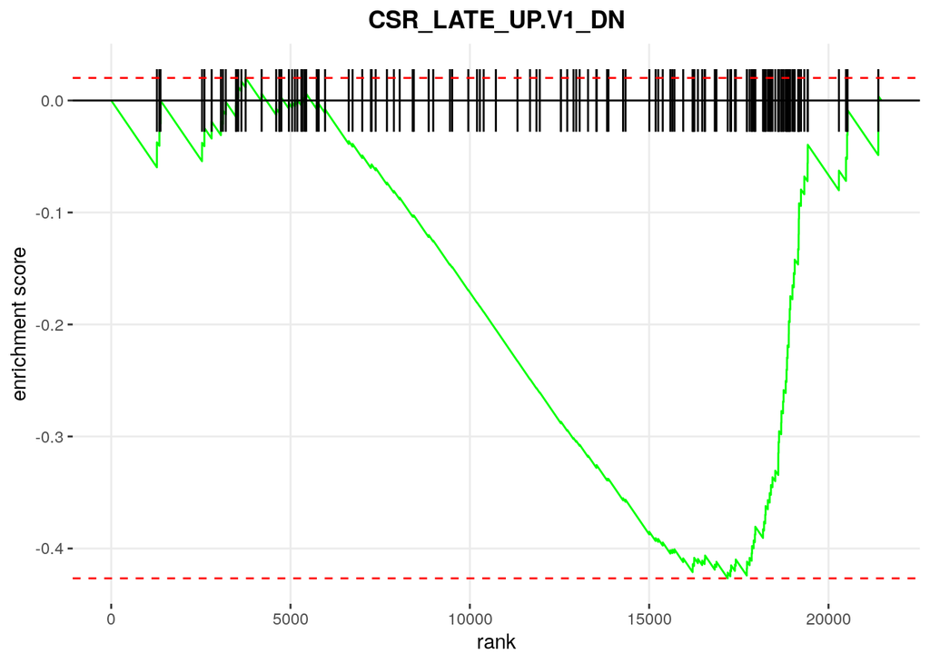

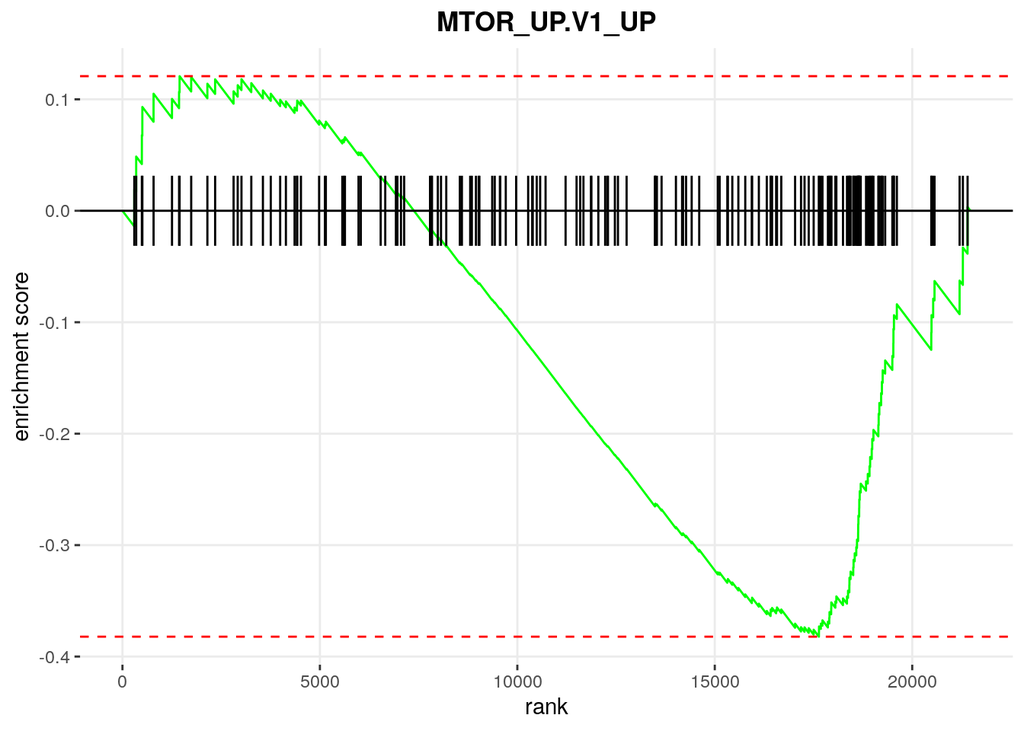

```r
#converts filtered_pathway to a vector
filt_down <- as.vector(filtered_pathway$pathway)

#Outputs an enrichment plot for genes with an NES less than -1.3. Outlines the format and design of the plot
for (i in filt_down){
    plt <- plotEnrichment(pathway = pathway[[i]],
    gseaParam = 1, ticksSize = 0.5, stats= rank) +
    labs(title=i) + theme(plot.title = element_text(hjust = 0.5, face="bold"))
    print(plt)
}
```

#NES Score Plots:

High NES Plots:

Cancer is a group of disorders and therefore the DEGs that apply in each separate type of cancer are different. The DEGs all have different normal functions. Genes can be DNA repair genes, tumour suppressor genes, onconogenes or genes with other functions. The up regulation or down regulation of these genes result in cancer.

EGFR (Epidermal Growth Factor Receptor): Up regulation of EGFR is observed in many cancers, including lung, breast, colorectal, and head and neck cancers. Mutation of EGFR is a biomarker of other cancers such as non-small cell lung cancer (NSCLC). EGFR is involved in cell signaling, more specifically a signalling pathway for cell proliferation. Mutation of this receptor can cause the signalling pathway for cell proliferation to be hindered. This has a tumourigensis effect and cells can evade of apoptosis.

BRCA1 (Breast Cancer Gene 1): This gene is a DNA repair genes that has a role in DNA stability and repairing double stranded breaks in DNA. Loss of BRCA1 causes genomic instability and the rick of cancer increases. BRCA1 is linked with ovarian and breast cancers. It’s mutation has also been linked with other cancers such as prostate cancer. Genetic screening for mutations in BRCA1 can be used as early detection and preventative measures can be taken to prevent breast and ovarian cancer.

TP53 (p53): TP53 is a tumour repressor gene that produces the p53 protein, a transcription factor, that plays a pivotal role in regulating cell growth, apoptosis, DNA repair, and maintaining genomic stability. p53 regulates the cell cycle and allows for DNA repair before moving forward in the cell cycle. It also triggers apoptosis in cells with irreparable DNA damage. Mutation of the TP53 promotes tumour development and progression. A mutation in the TP53 gene is one of the most prevalent mutations in human cancers.

VEGF (Vascular Endothelial Growth Factor): VEGF is a gene that codes for the VEGF protein that is a signalling protein involved in angiogenesis. A process of producing blood vessels that supply blood to new tumours. This supports tumour developement and progression. Enhanced vascularization supplies tumours with the oxygen and nutrients to grow. This enables metatsis which is when the cancer spreads and new tumours away are formed away from the original tumour.

DEGs are crucial biomarkers for identifying and treating different cancers. Their analysis can give us information about the molecular intricacies that will help us understand, identifying and treating different cancers based on the DEGs identified. With our developing knowledge about DEGs, there will be advancememts in cancer managemnet and therapeutics.